# Neighbourhood Context and Antibiotic Use Patterns

# 8 Summary: ICC and PCV

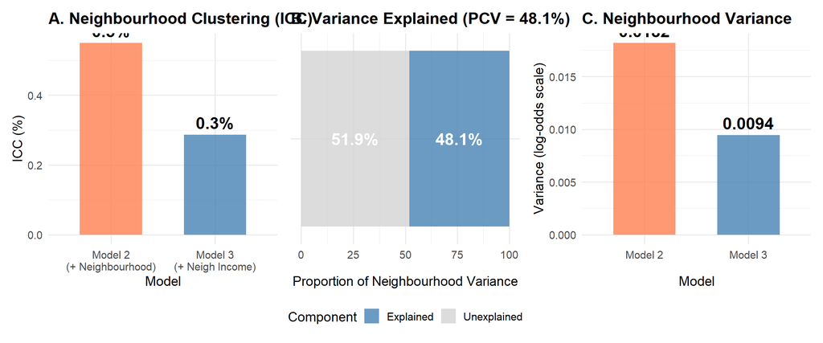

```r
# ICC comparison
p1 <- data.frame(
  Model = c("Model 2\n(+ Neighbourhood)", "Model 3\n(+ Neigh Income)"),
  ICC = c(icc_model2, icc_model3) * 100
) %>%
  ggplot(aes(x = Model, y = ICC, fill = Model)) +
  geom_col(alpha = 0.8, width = 0.6) +
  geom_text(aes(label = sprintf("%.1f%%", ICC)),
            vjust = -0.5, size = 6, fontface = "bold") +
  scale_fill_manual(values = c("coral", "steelblue")) +
  labs(title = "A. Neighbourhood Clustering (ICC)",
       y = "ICC (%)") +
  theme_minimal(base_size = 14) +
  theme(legend.position = "none",
        plot.title = element_text(face = "bold"))

# PCV visualization
p2 <- data.frame(
  Component = c("Explained", "Unexplained"),
  Percentage = c(pcv, 100 - pcv)
) %>%
  ggplot(aes(x = "", y = Percentage, fill = Component)) +
  geom_col(alpha = 0.8, width = 1) +
  geom_text(aes(label = sprintf("%.1f%%", Percentage)),
            position = position_stack(vjust = 0.5),
            size = 6, fontface = "bold", color = "white") +
  coord_flip() +
  scale_fill_manual(values = c("Explained" = "steelblue",
                                "Unexplained" = "lightgray")) +
  labs(title = sprintf("B. Variance Explained (PCV = %.1f%%)", pcv),
       y = "Proportion of Neighbourhood Variance") +
  theme_minimal(base_size = 14) +
  theme(plot.title = element_text(face = "bold"),
        axis.title.y = element_blank(),
        axis.text.y = element_blank(),
        legend.position = "bottom")

# Variance change
p3 <- data.frame(
  Model = factor(c("Model 2", "Model 3"), levels = c("Model 2", "Model 3")),
  Variance = c(var_neighbourhood_m2, var_neighbourhood_m3)
) %>%
  ggplot(aes(x = Model, y = Variance, fill = Model)) +
  geom_col(alpha = 0.8, width = 0.6) +
  geom_text(aes(label = sprintf("%.4f", Variance)),
            vjust = -0.5, size = 6, fontface = "bold") +
  scale_fill_manual(values = c("coral", "steelblue")) +
  labs(title = "C. Neighbourhood Variance",
       y = "Variance (log-odds scale)") +
  theme_minimal(base_size = 14) +
  theme(legend.position = "none",
        plot.title = element_text(face = "bold"))

(p1 | p2 | p3)
```

# 9 Key Findings

## 9.1 Summary Table

```r
summary_results <- data.frame(
  Metric = c("ICC (Model 2)", "ICC (Model 3)", "PCV",
             "Private GP OR"),
  Value = c(
    sprintf("%.1f%%", icc_model2 * 100),
    sprintf("%.1f%%", icc_model3 * 100),
    sprintf("%.1f%%", pcv),
    sprintf("%.2f", or_gp)
  ),
  Interpretation = c(
    "General neighbourhood effect",
    "After accounting for income",
    "Variance explained by income",
    "Effect of private vs public GP"
  )
)

kable(summary_results,
      caption = "Summary: Contextual Effects on Antibiotic Use",
      align = c("l", "c", "l"),
      col.names = c("Measure", "Value", "Interpretation")) %>%
  kable_styling(bootstrap_options = c("striped", "hover", "condensed"),
                full_width = FALSE) %>%
  column_spec(1, bold = TRUE, width = "10em") %>%
  column_spec(2, bold = TRUE, color = "white", background = "coral", width = "8em") %>%
  column_spec(3, width = "20em")
```

Summary: Contextual Effects on Antibiotic Use

| Measure | Value | Interpretation |
| --- | --- | --- |
| ICC (Model 2) | 0.5% | General neighbourhood effect |
| ICC (Model 3) | 0.3% | After accounting for income |
| PCV | 48.1% | Variance explained by income |
| Private GP OR | 0.89 | Effect of private vs public GP |

# 10 Conclusions

## 10.1 Neighbourhood Contextual Effects

**ICC = 0.5%**

- Minimal neighbourhood clustering
- Neighbourhoods are not strongly relevant for antibiotic use patterns

**PCV = 48.1%**

- Neighbourhood income explains 48.1% of neighbourhood variance
- Socioeconomic factors are major drivers

## 10.2 Policy Implications

```r
if (icc_model2 < 0.05) {
  cat("
**Universal Strategies Recommended:**

- Low neighbourhood clustering suggests population-wide interventions
- Focus on prescriber education and national guidelines
- GP type effects suggest healthcare system-level policies
- Monitor prescribing patterns at practice level, not neighbourhood
")
} else if (icc_model2 < 0.15) {
  cat("
**Mixed Approach:**

- Modest clustering supports combination of universal + targeted strategies
- Strengthen antibiotic stewardship in high-use neighbourhoods
- Address GP prescribing patterns (private vs public differences)
- Monitor both neighbourhood and practice-level variation
")
} else {
  cat("
**Neighbourhood-Targeted Interventions:**

- Strong clustering justifies geographic targeting
- Investigate local prescribing cultures and healthcare access
- Focus resources on high-use neighbourhoods
- Consider neighbourhood-specific interventions beyond income
")
}
```

**Universal Strategies Recommended:**

- Low neighbourhood clustering suggests population-wide interventions
- Focus on prescriber education and national guidelines
- GP type effects suggest healthcare system-level policies
- Monitor prescribing patterns at practice level, not neighbourhood

# 11 References - for the methods

Ghith N, Wagner P, Frølich A, Merlo J (2016) Short Term Survival after Admission for Heart Failure in Sweden: Applying Multilevel Analyses of Discriminatory Accuracy to Evaluate Institutional Performance. PLOS ONE 11(2): e0148187. https://doi.org/10.1371/journal.pone.0148187

**Analysis completed:** 2025-12-15 20:29:10.179853  
**Sample:** 30% random sample for computational efficiency  
**Focus:** ICC and PCV as key metrics for contextual analysis